# 单细胞转录组绘图和结果解读

zhuangzhenkun@genomics.cn

2020年05月29日

### 课前准备

一. 了解RNA-seq的基本原理  
二. 需提前在个人电脑的本地安装以下软件或包  
1.R-3.5.1以上 推荐安装R-3.6.1  
2.Rstudio  
3.Seurat3 R包 `install.packages('Seurat')`

### 课程主线：

1.从read count数据开始，进行聚类/差异基因分析，对差异基因进行基本的可视化。  
2.学习使用交互式可视化软件。

### 数据输入

```r
# install.packages("Seurat")安装Seurat,装过的下一步
library(dplyr)
library(Seurat)
# Load the PBMC dataset
counts <- Read10X("/opt/share/2020-05-29/pbmc_10k_v3_filtered_feature_bc_matrix/")
pbmc <- CreateSeuratObject(counts = counts, assay= 'RNA', project = "10X_RNA", min.cells = 5,min.features = 500) #创建Object
```

### Seurat Object 是一个S4类

显示Seurat3 常用的变量位置：Cluster分群信息：`object@active.ident`  
Metadata信息：`object@meta.data` Normalized 后的矩阵：`object@assays$RNA@data`  
tsne坐标信息：`pbmc@reductions$tsne@cell.embeddings`

```r
str(pbmc,max.level = 2)
```

```
## Formal class 'Seurat' [package "Seurat"] with 12 slots
##   ..@ assays      :List of 1
##   ..@ meta.data   :'data.frame': 11278 obs. of  3 variables:
##   ..@ active.assay: chr "RNA"
##   ..@ active.ident: Factor w/ 1 level "10X_RNA": 1 1 1 1 1 1 1 1 1 1 ...
##   .. ..- attr(*, "names")= chr [1:11278] "AAACCCAAGCGCCCAT" "AAACCCAAGGTTCCGC" "AAACCCACAGAGTTGG" "AAACCCACAGGTATGG" ...
##   ..@ graphs      : list()
##   ..@ neighbors   : list()
##   ..@ reductions  : list()
##   ..@ project.name: chr "10X_RNA"
##   ..@ misc        : list()
##   ..@ version     :Classes 'package_version', 'numeric_version'  hidden list of 1
##   ..@ commands    : list()
##   ..@ tools       : list()
```

### 稀疏矩阵特性

因为表达矩阵中存在大量的0值，转换为稀疏矩阵可以大大减小储存空间

```r
pbmc
```

```
## An object of class Seurat
## 19089 features across 11278 samples within 1 assay
## Active assay: RNA (19089 features)
```

```r
pbmc@assays$RNA@data[c("CD3D", "TCL1A","MS4A1"),1:30]
```

```
## 3 x 30 sparse Matrix of class "dgCMatrix"
```

```
##    [[ suppressing 30 column names 'AAACCCAAGCGCCCAT', 'AAACCCAAGGTTCCGC', 'AAACCCACAGAGTTGG' ... ]]
```

```
##
## CD3D  2 . . . . . 8 4 6 . . . . . 2 2 5  . 3 . 8 .  . 4 . 1 . 3 3 1
## TCL1A . . . . 3 . . . . . . . . . . . .  . 1 1 . . 19 . . . 4 . . .
## MS4A1 . . . . 3 . . . . . . . 1 . . . . 15 . 3 . .  . . . . 4 . . .
```

稀疏矩阵与普通矩阵之间的互相转换：需要`library(matrix)`。`library(Seurat）`时，matrix包 已经自动加载  
`Mat1 <- as(Mat2, "sparseMatrix")` ** 普通矩阵转化为稀疏矩阵  
`Mat2 <- as.matrix(Mat1)` **稀疏矩阵转化为普通矩阵

```r
dense.size <- object.size(as.matrix(pbmc@assays$RNA@data))
sparse.size <- object.size(pbmc@assays$RNA@data)
as.numeric(dense.size/sparse.size)
```

```
## [1] 5.773142
```

原矩阵的大小是稀疏矩阵的5.8倍

### 数据质控&过滤

线粒体基因以MT-开头。若细胞在裂解前状态不好，线粒体会破裂导致提取到线粒体相关RNA。因此一般会用单个细胞中线粒体基因表达的比例来表征细胞状态，若比例过高，则视为低质量细胞过滤。

`VlnPlot` 制作提琴图  
`FeatureScatter` 制作散点图

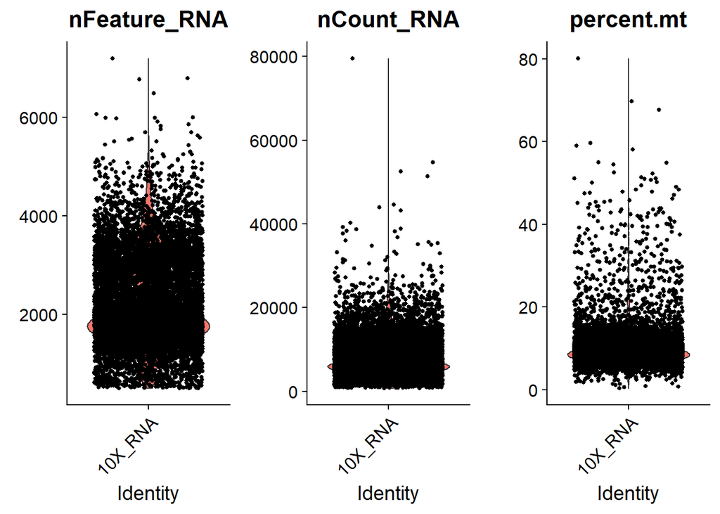

```r
pbmc[["percent.mt"]] <- PercentageFeatureSet(pbmc, pattern = "^MT-")
VlnPlot(pbmc, features = c("nFeature_RNA", "nCount_RNA", "percent.mt"), ncol = 3)
```

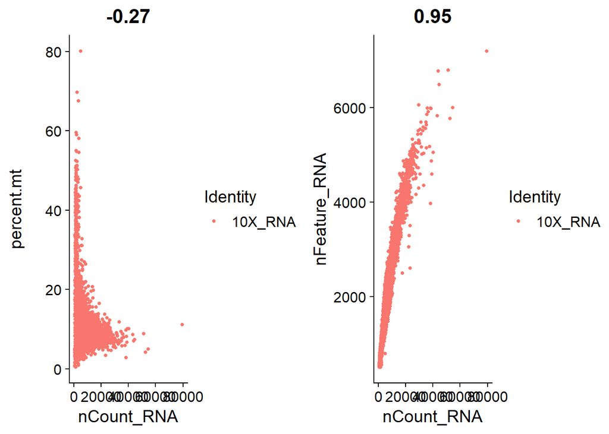

```r
plot1 <- FeatureScatter(pbmc, feature1 = "nCount_RNA", feature2 = "percent.mt")
plot2 <- FeatureScatter(pbmc, feature1 = "nCount_RNA", feature2 = "nFeature_RNA")
CombinePlots(plots = list(plot1, plot2))
```

线粒体基因百分比高,细胞质量差

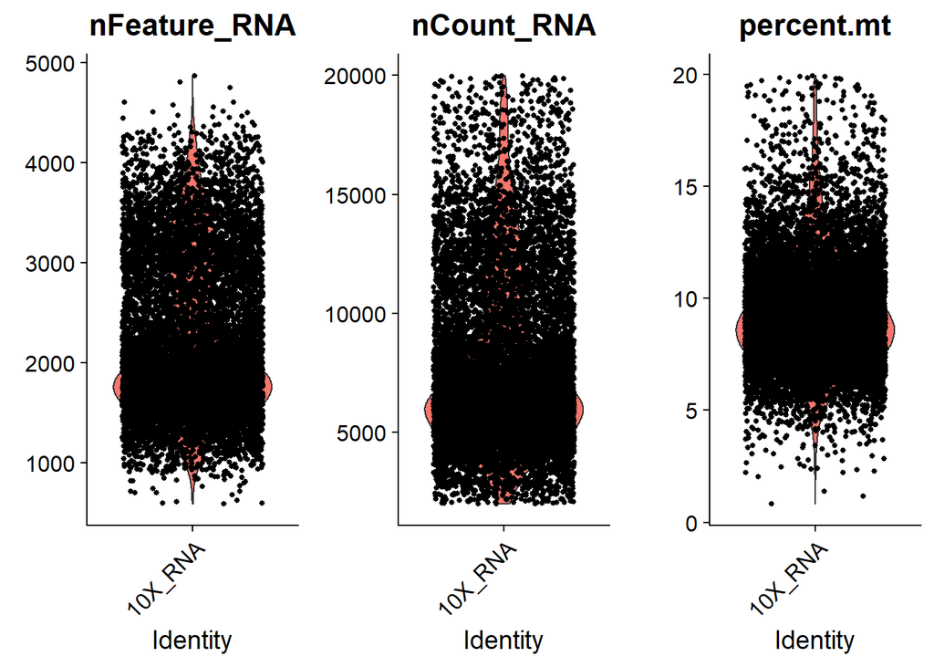

```r
pbmc <- subset(pbmc, subset = nCount_RNA > 2000 & nCount_RNA < 20000 &  percent.mt < 20)
## 检测UMI数目大于2000且小于20000检测基因数过少,细胞质量差,过多可能是双细胞
VlnPlot(pbmc, features = c("nFeature_RNA", "nCount_RNA", "percent.mt"), ncol = 3)
```

具体选定的cutoff可以根据质控指标的数据分布微调

查看质控信息

```r
head(pbmc@meta.data)
```

```
##                  orig.ident nCount_RNA nFeature_RNA percent.mt
## AAACCCAAGCGCCCAT    10X_RNA       2204         1087   2.359347
## AAACCCACAGAGTTGG    10X_RNA       5884         1836  10.757988
## AAACCCACAGGTATGG    10X_RNA       5530         2216   7.848101
## AAACCCACATAGTCAC    10X_RNA       5106         1615  10.830396
## AAACCCACATCCAATG    10X_RNA       4572         1800   8.989501
## AAACCCAGTGGCTACC    10X_RNA       6702         1965   6.326470
```

可以根据质控矩阵自行用ggplot2 画图

### 数据标准化

```r
pbmc <- NormalizeData(pbmc, normalization.method = "LogNormalize", scale.factor = 10000)
```

`LogNormalize`: Feature counts for each cell are divided by the total counts for that cell and multiplied by the scale.factor. This is then natural-log transformed using log1p.

`? NormalizeData`

### S3 method for default

NormalizeData(object, normalization.method = “LogNormalize”, scale.factor = 10000, margin = 1, block.size = NULL, verbose = TRUE, …)

`scale.factor` —- 将每个细胞的UMI数目normalize 到与scale.factor一样的水平

```r
pbmc@assays$RNA@data[c("CD3D", "TCL1A", "MS4A1"), 1:30]
```

```
## 3 x 30 sparse Matrix of class "dgCMatrix"
```

```
##    [[ suppressing 30 column names 'AAACCCAAGCGCCCAT', 'AAACCCACAGAGTTGG', 'AAACCCACAGGTATGG' ... ]]
```

```
##
## CD3D  2.309999 . . .        . 2.560071 1.893495 2.499577 . . . .         .
## TCL1A .        . . 1.927956 . .        .        .        . . . .         .
## MS4A1 .        . . 1.927956 . .        .        .        . . . 0.6018864 .
##
## CD3D  1.492249 1.635873 2.117838 1.888837 .        2.362195 . .
## TCL1A .        .        .        1.054506 1.085584 .        . 2.88788
## MS4A1 .        .        .        .        1.929128 .        . .
##
## CD3D  1.681746 . 1.097813 .        1.393158 1.597492 0.964161 . .
## TCL1A .        . .        2.285441 .        .        .        . .
## MS4A1 .        . .        2.285441 .        .        .        . .
```

### 寻找high variable genes

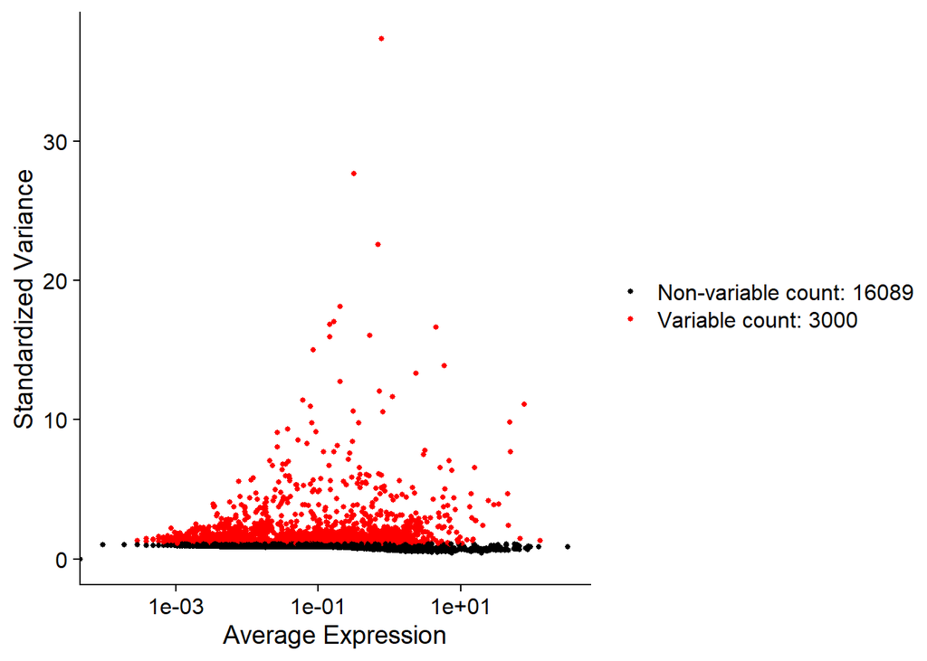

```r
pbmc <- FindVariableFeatures(pbmc, selection.method = "vst", nfeatures = 3000)
#除了vst方法外，还有mean.var.plot和 dispersion
plot1 <- VariableFeaturePlot(pbmc)
plot1
```

### 消除量纲

不同的基因，其本底表达量不同，在数据分布上，数值越高的集合，其标准差也会偏大。因此需要将各个基因的表达水平标准化到一个刻度上。也就是统计学上熟知的Z-score

```r
all.genes <- rownames(pbmc)
pbmc <- ScaleData(pbmc, features = all.genes)
```

### 主成分分析（PCA）

使用先前找到的High variable genes 作为输入，计算主成分

```r
pbmc <- RunPCA(pbmc, features = VariableFeatures(object = pbmc), npcs = 50)
```

```
## PC_ 1
## Positive:  CST3, FCN1, MNDA, LYZ, FGL2, S100A9, CTSS, CSTA, PSAP, NCF2
##     SERPINA1, AIF1, TYMP, GRN, VCAN, S100A8, TYROBP, MS4A6A, FTL, CD68
##     MPEG1, CYBB, LGALS1, CPVL, LST1, FTH1, CD14, CLEC7A, KLF4, S100A12
## Negative:  LTB, CD3E, TRAC, CD3D, TRBC2, IL32, LCK, ETS1, CD3G, IL7R
##     TCF7, ISG20, CD69, CD27, CD7, LDHB, CD247, ARL4C, SPOCK2, CD2
##     BCL11B, GZMM, TRBC1, FCMR, RORA, SYNE2, NOSIP, LAT, SKAP1, PIK3IP1
## PC_ 2
## Positive:  CD79A, MS4A1, IGHM, BANK1, HLA-DQA1, CD79B, IGHD, LINC00926, CD22, HLA-DQB1
##     CD74, BCL11A, TNFRSF13C, RALGPS2, HLA-DRB1, TCL1A, HLA-DRA, HLA-DPB1, IGKC, HLA-DPA1
##     FAM129C, VPREB3, HLA-DQA2, SPIB, CD37, FCER2, HLA-DRB5, MEF2C, SWAP70, FCRL2
## Negative:  IL32, CD247, GZMM, CD3E, CD7, CTSW, S100A4, GZMA, LCK, NKG7
##     CST7, CD3D, KLRB1, PRF1, ANXA1, RORA, ARL4C, TRAC, CCL5, TMSB4X
##     SAMD3, KLRG1, IL7R, CD3G, ZAP70, ITGB2, CD2, KLRD1, GNLY, TRBC1
## PC_ 3
## Positive:  GZMB, GNLY, KLRF1, CLIC3, NKG7, PRF1, KLRD1, SPON2, FGFBP2, CST7
##     ADGRG1, GZMA, CCL4, HOPX, TRDC, FCGR3A, IL2RB, CTSW, TBX21, GZMH
##     TTC38, RHOC, MYOM2, MATK, AKR1C3, CD160, APOBEC3G, C12orf75, S1PR5, PTGDR
## Negative:  IL7R, TCF7, MAL, LDHB, JUNB, TRABD2A, LEF1, RCAN3, CD3G, CD3D
##     NOSIP, TRAC, CCR7, SERINC5, PIK3IP1, CD27, CAMK4, VIM, SLC2A3, PASK
##     LTB, BCL11B, FOSB, INPP4B, TSHZ2, NELL2, CD6, RGCC, RGS10, TRAT1
## PC_ 4
## Positive:  MT-CO1, CYBA, NKG7, PRF1, GNLY, KLRD1, KLRF1, CST7, GZMA, HOPX
##     SPON2, FGFBP2, ADGRG1, EFHD2, APOBEC3G, CCL4, MATK, TRDC, IL2RB, TBX21
##     CD160, ITGB2, GZMH, TTC38, MYOM2, IFITM2, S1PR5, CD37, CTSW, FCGR3A
## Negative:  PPBP, TUBB1, CAVIN2, PF4, GNG11, SPARC, CLU, PRKAR2B, GP9, TREML1
##     CMTM5, ITGA2B, CTTN, MPIG6B, ACRBP, PTCRA, CLDN5, TMEM40, C2orf88, HIST1H2AC
##     CD9, CLEC1B, MYL9, MTURN, AC147651.1, AP001189.1, TSC22D1, NRGN, PDZK1IP1, GNAZ
## PC_ 5
## Positive:  LILRA4, SERPINF1, CLEC4C, IL3RA, SCT, TPM2, SMPD3, DNASE1L3, LRRC26, PLD4
##     TNFRSF21, GAS6, LINC00996, SCN9A, RHEX, LAMP5, DERL3, SCAMP5, ITM2C, PHEX
##     ZFAT, UGCG, KCNK17, MAP1A, PACSIN1, CYP46A1, SHD, AC119428.2, ASIP, PPM1J
## Negative:  MS4A1, CD79A, LINC00926, PDLIM1, CD79B, IGHD, BANK1, CD22, TNFRSF13C, FCER2
##     GNLY, RALGPS2, VPREB3, KLRD1, KLRF1, FGFBP2, FCRL1, TSPAN33, PRF1, ADGRG1
##     ADAM28, SWAP70, FCRL2, LAT2, CD40, PLPP5, NKG7, CCL4, P2RX5, HLA-DOB
```

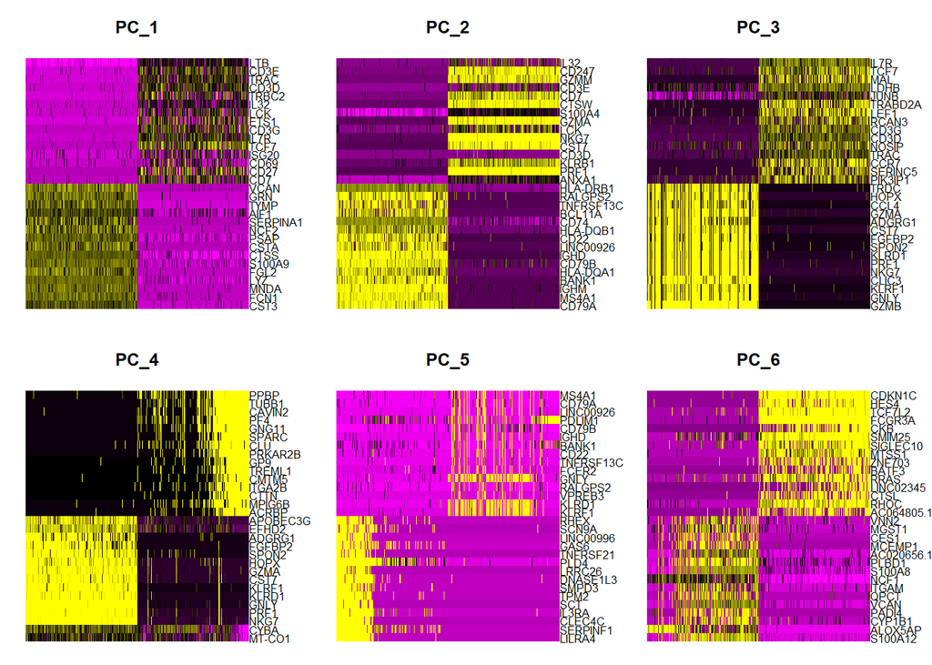

```r
DimHeatmap(pbmc, dims = 1:6, cells = 500, balanced = TRUE)
```

### 如何确定使用几个PC进行下游分析？

方法1. 如果你确定你的研究所关注的异质性基因类型，那可以用有监督的方法配合基因注释或者通路富集选择PC  
方法2.

```r
#此步骤耗时较长可选择运行
#pbmc <- JackStraw(pbmc, num.replicate = 100)
#pbmc <- ScoreJackStraw(pbmc, dims = 1:20)
#JackStrawPlot(pbmc, dims = 1:20)
```

方法3：根据各个PC的标准差判断

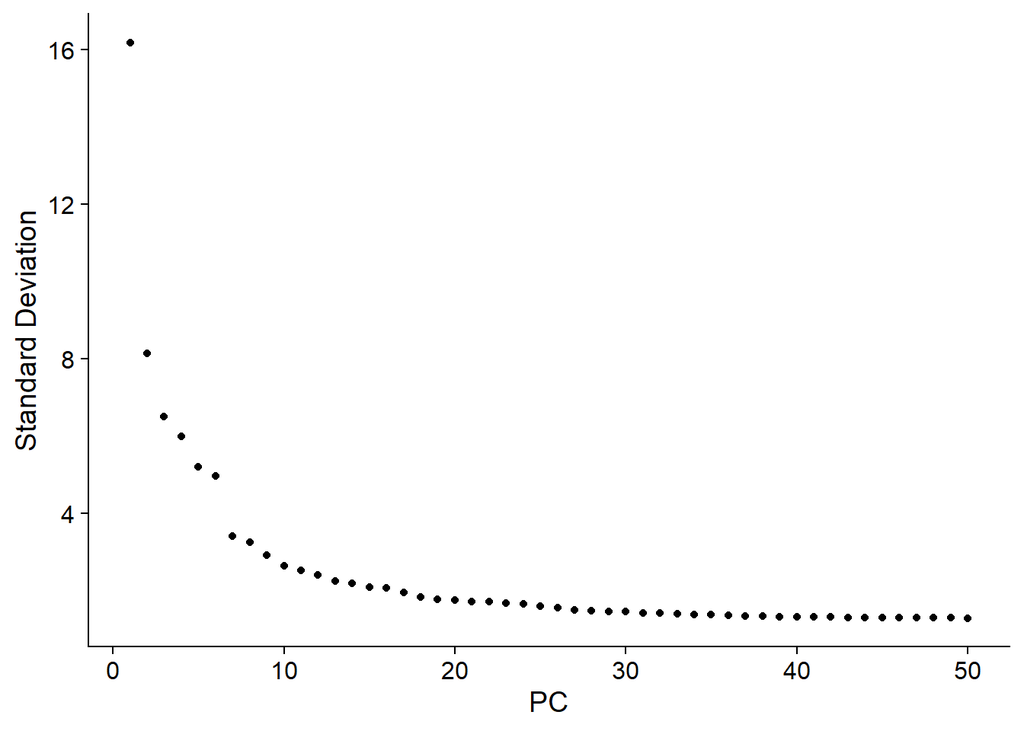

```r
ElbowPlot(pbmc,ndims = 50)
```

### 聚类

```r
pbmc <- FindNeighbors(pbmc, dims = 1:30)
pbmc <- FindClusters(pbmc, resolution = 0.5)
```

```
## Modularity Optimizer version 1.3.0 by Ludo Waltman and Nees Jan van Eck
##
## Number of nodes: 10499
## Number of edges: 417415
##
## Running Louvain algorithm...
## Maximum modularity in 10 random starts: 0.9200
## Number of communities: 19
## Elapsed time: 1 seconds
```

```r
#分类结果存在pbmc@active.ident 中，也可以通过Idents(pbmc)调出查看
head(Idents(pbmc), 5)
```

```
## AAACCCAAGCGCCCAT AAACCCACAGAGTTGG AAACCCACAGGTATGG AAACCCACATAGTCAC
##                1                0                6                4
## AAACCCACATCCAATG
##                6
## Levels: 0 1 2 3 4 5 6 7 8 9 10 11 12 13 14 15 16 17 18
```

### 聚类结果可视化

```r
pbmc <- RunUMAP(pbmc, dims = 1:30)
```

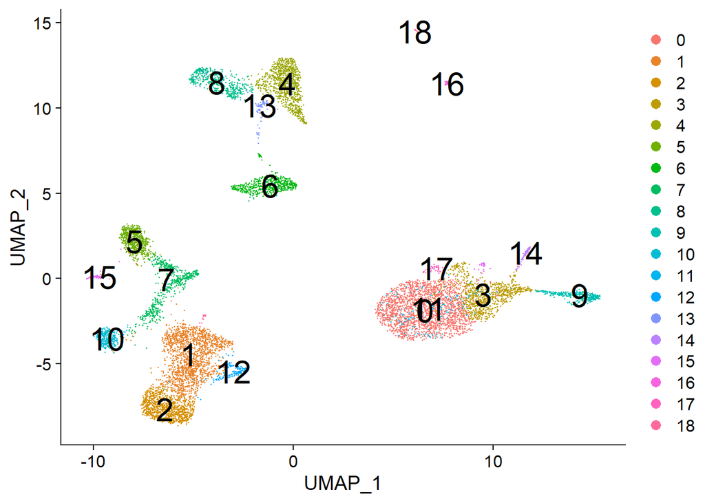

```r
DimPlot(pbmc, reduction = "umap",label=TRUE,label.size=8)
```

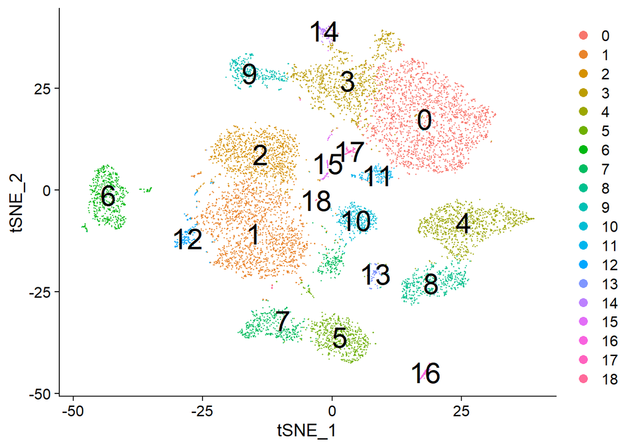

```r
pbmc <- RunTSNE(pbmc, dims = 1:30)
DimPlot(pbmc, reduction = "tsne",label=TRUE,label.size=8)
```

可在命令行运行`? FindClusters`查看函数具体参数

```r
pbmc <- FindClusters(pbmc, resolution = 0.5, algorithm = 1)
```

```
## Modularity Optimizer version 1.3.0 by Ludo Waltman and Nees Jan van Eck
##
## Number of nodes: 10499
## Number of edges: 417415
##
## Running Louvain algorithm...
## Maximum modularity in 10 random starts: 0.9200
## Number of communities: 19
## Elapsed time: 1 seconds
```

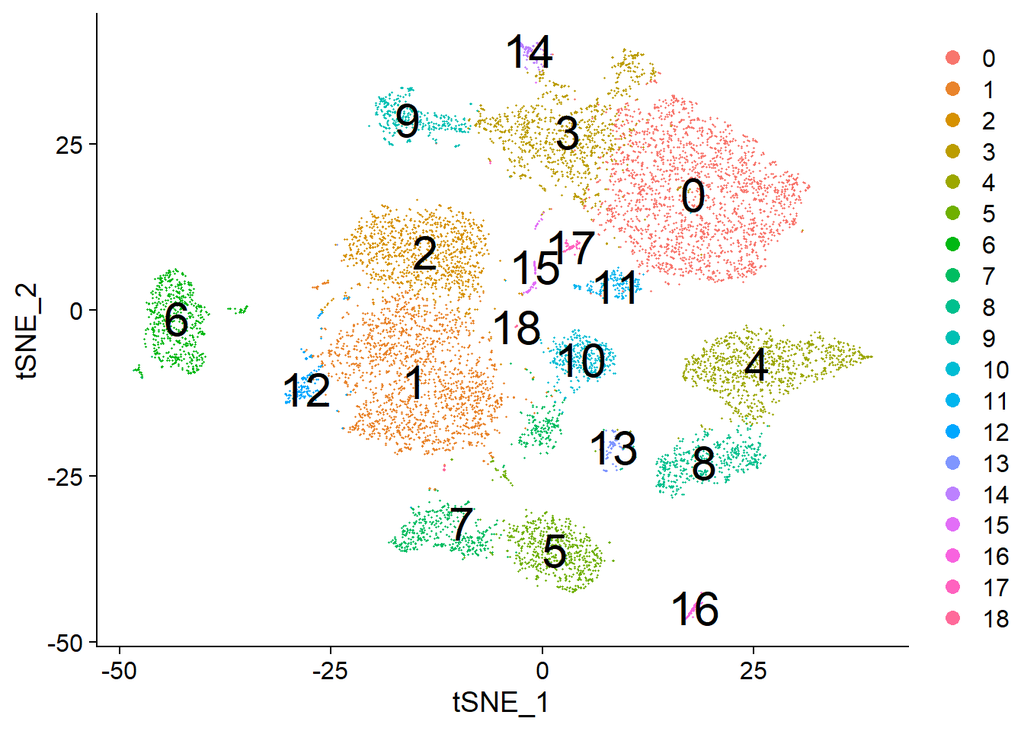

```r
DimPlot(pbmc, reduction = "tsne",label=TRUE,label.size=8)
```

```r
pbmc <- FindClusters(pbmc, resolution = 0.5, algorithm = 2)
```

```
## Modularity Optimizer version 1.3.0 by Ludo Waltman and Nees Jan van Eck
##
## Number of nodes: 10499
## Number of edges: 417415
##
## Running Louvain algorithm with multilevel refinement...
## Maximum modularity in 10 random starts: 0.9202
## Number of communities: 19
## Elapsed time: 2 seconds
```

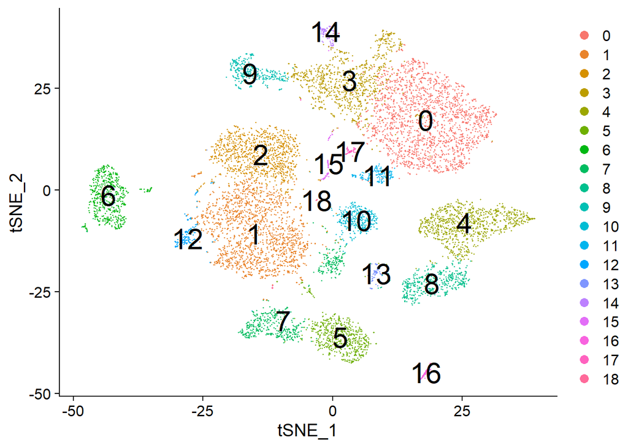

```r
DimPlot(pbmc, reduction = "tsne",label=TRUE,label.size=8)
```

```r
pbmc <- FindClusters(pbmc, resolution = 0.5, algorithm = 3)
```

```
## Modularity Optimizer version 1.3.0 by Ludo Waltman and Nees Jan van Eck
##
## Number of nodes: 10499
## Number of edges: 417415
##
## Running smart local moving algorithm...
## Maximum modularity in 10 random starts: 0.9202
## Number of communities: 19
## Elapsed time: 9 seconds
```

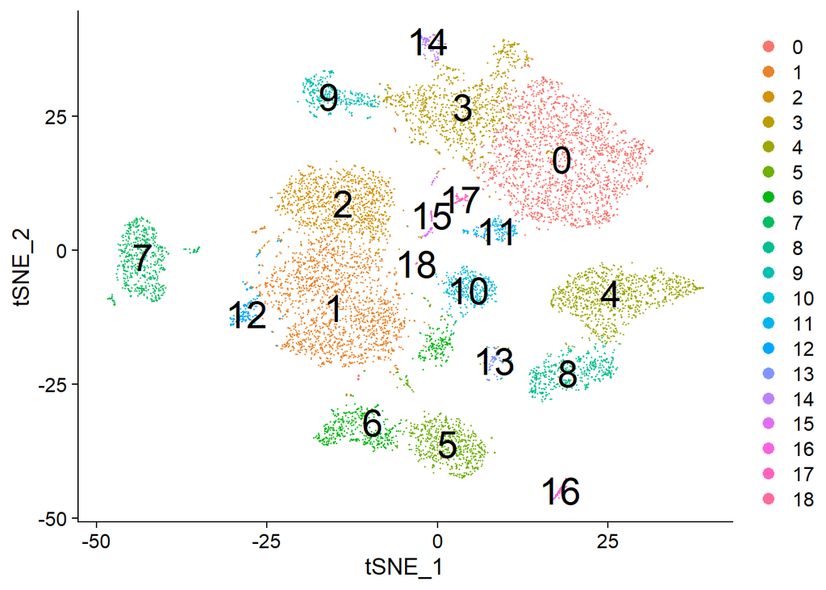

```r
DimPlot(pbmc, reduction = "tsne",label=TRUE,label.size=8)
```

### Seurat object 保存

```r
# saveRDS(pbmc, file = "pbmc_10K.rds")
# 读取rds方式：
# pbmc<-readRDS ("pbmc_10K.rds")
```

### 关于基因表达的多种可视化方法

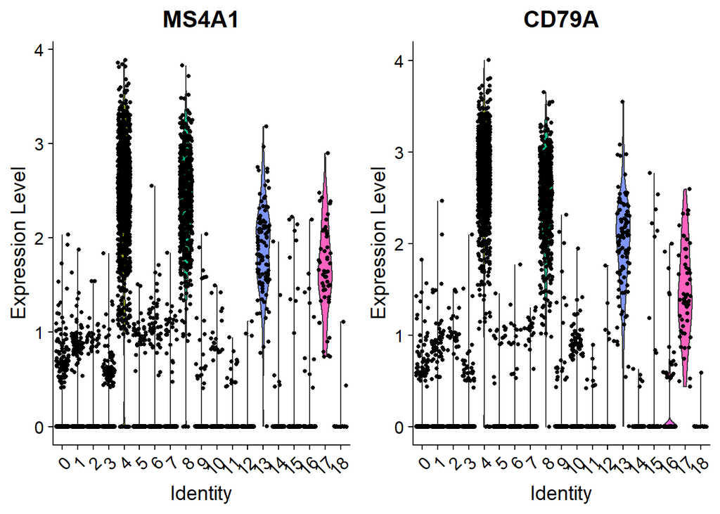

```r
VlnPlot(pbmc, features = c("MS4A1", "CD79A")) ## 小提琴图
```

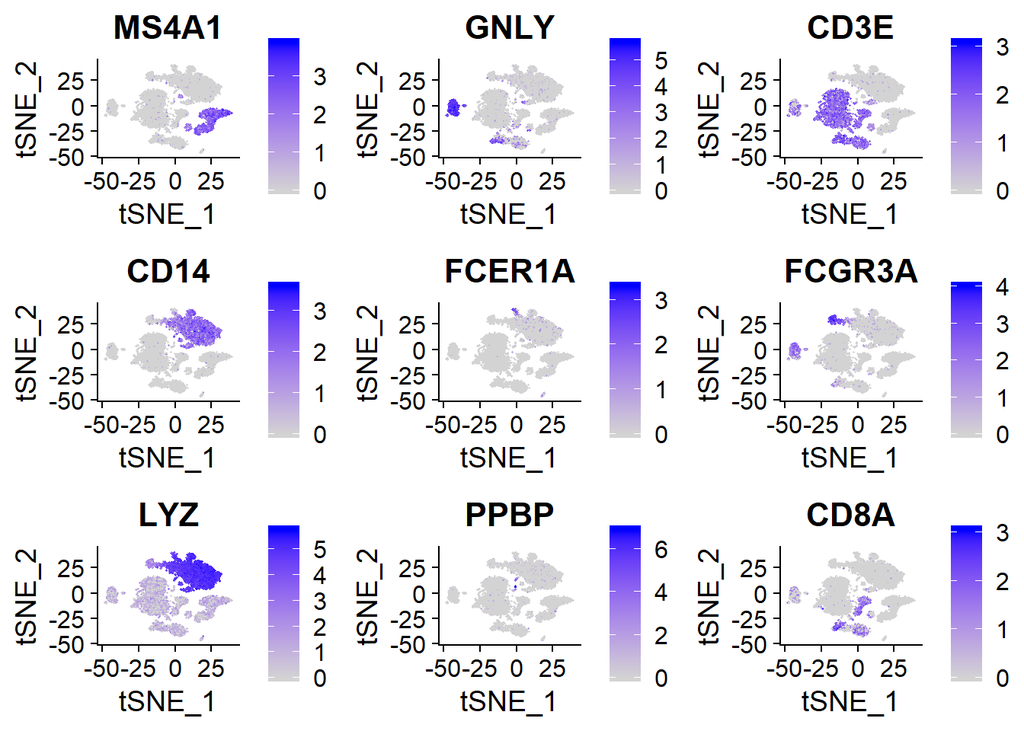

```r
##基于umap/tsne的表达图
FeaturePlot(pbmc, features = c("MS4A1", "GNLY", "CD3E", "CD14", "FCER1A", "FCGR3A", "LYZ", "PPBP", "CD8A"),reduction = "tsne")
```

### 差异表达基因

每个cluster，计算它相对于其他cluster的差异表达基因

```r
#只输出上调结果最低表达百分比  Log(Fold change)的cut off
pbmc.markers <- FindAllMarkers(pbmc, only.pos = TRUE, min.pct = 0.5, logfc.threshold = 1, verbose = F)
```

单独计算cluster1相对于其他cluster的差异表达基因

```r
cluster1.markers <- FindMarkers(pbmc, ident.1 = 1, min.pct = 0.5, logfc.threshold = 1)
```

单独计算cluster5相对于cluster3的差异表达基因

```r
cluster5vs3.markers <- FindMarkers(pbmc, ident.1 = 5, ident.2 = 3, min.pct = 0.5, logfc.threshold = 1)
```

画每个cluster中top10差异基因的热图

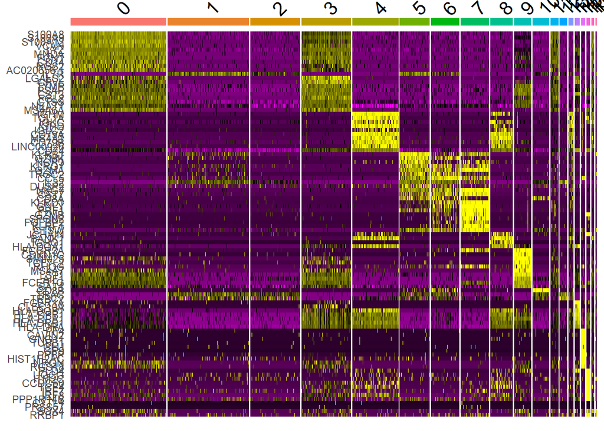

```r
top10 <- pbmc.markers %>% group_by(cluster) %>% top_n(n = 10, wt = avg_logFC)
DoHeatmap(pbmc, features = top10$gene) + NoLegend()
```